# VISIONS'18: Tucker trawl 2018-07-21

Cruise number: RR1812 (R/V Roger Revelle)

This notebook shows an estimation of where the time-depth trajectory of the Tucker trawl tow on 2018-07-21 was with respect to the animals in the water column (observed through ADCP).

## Loading ADCP raw beam data

First let's load in some libraries we will need to read and plot the data.

```python
import os, re, glob
import numpy as np
import matplotlib.pyplot as plt
import datetime
import arlpy   # ARL underwater acoustics toolbox
from mpl_toolkits.axes_grid1 import make_axes_locatable

# sys.path.append('/Users/wujung/adcpcode/programs')
from pycurrents.adcp.rdiraw import Multiread
import adcp_func
```

Find out what are the available ADCP raw files.

```python
# Set up paths and params
pname_150 = '/Volumes/current_cruise/adcp/RR1812/raw/os150/'
fname_150 = glob.glob(pname_150+'rr2018_202*.raw')
fname_150.sort()   # sort filename
fname_150
```

```
['/Volumes/current_cruise/adcp/RR1812/raw/os150/rr2018_202_03070.raw',
 '/Volumes/current_cruise/adcp/RR1812/raw/os150/rr2018_202_07200.raw',
 '/Volumes/current_cruise/adcp/RR1812/raw/os150/rr2018_202_14400.raw',
 '/Volumes/current_cruise/adcp/RR1812/raw/os150/rr2018_202_21600.raw',
 '/Volumes/current_cruise/adcp/RR1812/raw/os150/rr2018_202_28800.raw',
 '/Volumes/current_cruise/adcp/RR1812/raw/os150/rr2018_202_36000.raw',
 '/Volumes/current_cruise/adcp/RR1812/raw/os150/rr2018_202_43200.raw',
 '/Volumes/current_cruise/adcp/RR1812/raw/os150/rr2018_202_50400.raw',
 '/Volumes/current_cruise/adcp/RR1812/raw/os150/rr2018_202_57600.raw',
 '/Volumes/current_cruise/adcp/RR1812/raw/os150/rr2018_202_64800.raw',
 '/Volumes/current_cruise/adcp/RR1812/raw/os150/rr2018_202_72000.raw',
 '/Volumes/current_cruise/adcp/RR1812/raw/os150/rr2018_202_79200.raw']
```

It's a bit of a guess work to figure out which files contain the section during the net tow.

We know the last number string in the filename are the number of seconds since 00:00 of the day. The net tow was in water around 03:26 UTC time = 12360 secs. This means files `rr2018_202_07200.raw` and `rr2018_202_14400.raw` should cover the section of the net tow.

Let's give it a try!

```python
m_150,data_150,param_150 = adcp_func.load_raw_files([pname_150+'rr2018_202_07200.raw',pname_150+'rr2018_202_14400.raw'])
```

```
Loading files... (os150.0)
  rr2018_202_07200.raw
  rr2018_202_14400.raw
```

Next we grab the time stamp from the ADCP raw data stream.

```python
# set up x-axis (time stamp) for ADCP data
ping_jump_150 = int(np.floor(data_150.dday.shape[0]/8))
ping_num_150 = np.arange(0,data_150.amp1.shape[0],ping_jump_150)
time_str_150 = [str('%02d'%data_150.rVL['Hour'][x])+':'+str('%02d'%data_150.rVL['Minute'][x]) for x in ping_num_150]
```

Let's plot and check if the data make sense.

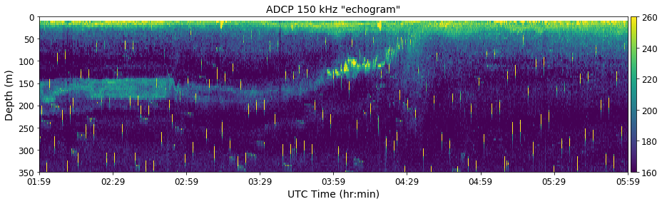

```python
val_mtx = data_150.amp1-param_150['absorption']-2*param_150['spreading_loss']
actual_depth_bin = np.round(param_150['range'],2)

fig = plt.figure(figsize=(15,4))
ax = fig.add_subplot(1,1,1)
im = ax.imshow(val_mtx.T,aspect='auto',interpolation='none',\
               extent=[0,val_mtx.shape[0],actual_depth_bin[-1],actual_depth_bin[0]],\
               vmin=160, vmax=260)
divider = make_axes_locatable(ax)
cax = divider.append_axes("right", size="1%", pad=0.05)
cbar = plt.colorbar(im,cax=cax)
cbar.ax.tick_params(labelsize=12)
ax.set_xticks(ping_num_150)
ax.set_xticklabels(time_str_150,fontsize=12)
ax.set_xlabel('UTC Time (hr:min)',fontsize=14)
ax.set_yticklabels(np.arange(0,400,50),fontsize=12)
ax.set_ylabel('Depth (m)',fontsize=14)
ax.set_ylim([350,0])
ax.set_title('ADCP 150 kHz "echogram"',fontsize=14)
plt.show()
```

## Loading net time-depth trajectory

Let's now try putting the net tow time-depth trajectory onto the echogram to see which were the layers we actually sampled.

```python
import pandas as pd
from pytz import common_timezones
```

```python
csv_pname = '/Volumes/Transcend/Dropbox/Z_wjlee/20180719_ooi_cruise/net_tow/'
csv_fname = '20180721_EAO600m_tow.csv'
```

```python
net = pd.read_csv(csv_pname+csv_fname,\
                 names=['Index','Device_ID','File_ID',\
                        'year','month','day','hour','minute','second',\
                        'Offset','Pressure','Temperature'])
```

```python
net['second'] = net['Offset']
```

## Plotting net time-depth trajectory on ADCP echogram

Now we mess around with the timestamps from the ADCP and the time-depth sensor on the net. The goal is to plot the time-depth trajectory directly on the ADCP echogram.

First we create a `datetime` string for the time-depth sensor on the net.

```python
net_timestamp = pd.to_datetime(net.loc[:, 'year':'second'])
net_timestamp = net_timestamp.dt.tz_localize('US/Pacific').dt.tz_convert('UTC')  # convert from Pacific to UTC
```

```python
net_depth = pd.Series((net['Pressure']-1013.25)*0.010197442889221,name='depth')
```

```python
net = pd.Series(net_depth.values,index=net_timestamp.values)
```

And then we create a `datetime` string for the ADCP data.

```python
adcp_timestack = np.vstack((data_150.rVL['Year']+2000,data_150.rVL['Month'],data_150.rVL['Day'],\
                             data_150.rVL['Hour'],data_150.rVL['Minute'],data_150.rVL['Second'])).T
```

```python
adcp_timestamp = pd.to_datetime(pd.DataFrame(adcp_timestack,columns=['year','month','day','hour','minute','second']))
adcp_timestamp = adcp_timestamp.dt.tz_localize('UTC')
```

Now we want to interpolate the net time-depth trajectory onto the same time indices as the ADCP data.

```python
x = pd.concat([net, pd.Series(index=adcp_timestamp)])
net_depth_on_adcp_timestamp = x.groupby(x.index).first().sort_index().interpolate(method='nearest')[adcp_timestamp]
```

And then we are ready to plot them together!

```python
val_mtx = data_150.amp1-param_150['absorption']-2*param_150['spreading_loss']
actual_depth_bin = np.round(param_150['range'],2)
val_mtx.shape
```

```
(6129, 80)
```

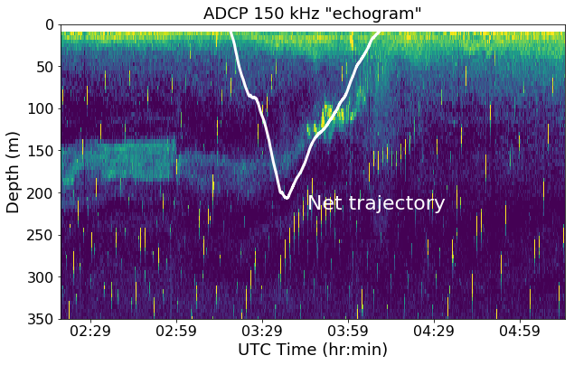

```python
# Plotting
# ADCP echogram
fig = plt.figure(figsize=(10,6))
ax = fig.add_subplot(1,1,1)
im = ax.imshow(val_mtx.T,aspect='auto',interpolation='none',\
               extent=[500,5000,actual_depth_bin[-1],actual_depth_bin[0]],\
               vmin=160, vmax=260)
# divider = make_axes_locatable(ax)
# cax = divider.append_axes("right", size="1%", pad=0.05)
# cbar = plt.colorbar(im,cax=cax)
# cbar.ax.tick_params(labelsize=14)
ax.set_xticks(ping_num_150)
ax.set_xticklabels(time_str_150,fontsize=16)
ax.set_xlabel('UTC Time (hr:min)',fontsize=18)
ax.set_yticklabels(np.arange(0,400,50),fontsize=16)
ax.set_ylabel('Depth (m)',fontsize=18)
ax.set_ylim([350,0])
ax.set_title('ADCP 150 kHz "echogram"',fontsize=18)

# Net tow trajectory
ax.plot(net_depth_on_adcp_timestamp.values,color='w',linewidth=3)

# Annotation
ax.text(x=2700,y=220,s='Net trajectory',color='w',fontsize=22)
# ax.annotate('Net trajectory', xy=(3000, 200), xytext=(3000, 230),
#             arrowprops=dict(facecolor='w', edgecolor='w', shrink=0.05))

plt.savefig('/Volumes/Transcend/Dropbox/Z_wjlee/20180719_ooi_cruise/net_tow/2018-07-21-adcp-tow.png',dpi=150)
plt.show()
```

## Messing around with seaborn but it didn't quite work...

```python
adcp_depth = pd.Series(actual_depth_bin,name='depth')
```

```python
# Convert ADCP echogram to DataFrame
adcp_echogram = pd.DataFrame(val_mtx)
```

```python
adcp_echogram.shape
```

```
(6129, 80)
```

```python
adcp_echogram.columns = adcp_depth
adcp_echogram.index = adcp_timestamp.dt.strftime('%H:%M')
```

```python
adcp_echogram
```

[output not shown]

6129 rows × 80 columns

```python
idx_jump = int(np.floor(adcp_echogram.shape[0]/8))
idx_cnt = np.arange(0,adcp_echogram.shape[0],idx_jump)
adcp_echogram.shape
```

```
(6129, 80)
```

```python
import seaborn as sns
sns.set()
```

```python
fig = plt.figure(figsize=(16,4))
ax = fig.add_subplot(1,1,1)
g = sns.heatmap(adcp_echogram.T,ax=ax,cmap='viridis',vmax=260,vmin=160,xticklabels=1000,yticklabels=10)

g.set_xlabel('UTC Time (hr:min)',fontsize=16,fontweight='bold')
g.set_ylabel('Depth (m)',fontsize=16,fontweight='bold')
sns.set_style("ticks")
g.tick_params(labelsize=14)

sns.lineplot(data=net_td)
# net_td.plot(ax=ax)
# ax.plot(net_td.index,net_td.depth,color='w',linewidth=10)
# sns.lineplot(data=net_td,color='w')
# sns.lineplot(data=net_td,color='w',alpha=0.7)

plt.show()
```

[output not shown]

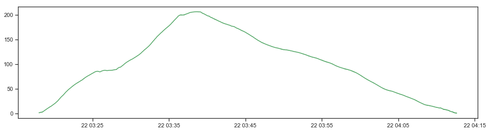

```python
fig = plt.figure(figsize=(16,4))
ax = fig.add_subplot(1,1,1)
ax.plot(net_timestamp,net_td.depth,color='g')
```

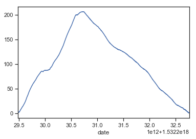

```python
sns.tsplot(data=net_td.depth,time=net_td.index)
```

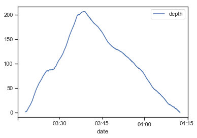

```python
net_td.plot()
```

```python
type(net_depth_on_adcp_timestamp)
```

```
pandas.core.series.Series
```

```python
pd.concat([data, ts]).sort_index().interpolate().reindex(ts.index)
```

```
2013-01-01 01:11:21   -0.478985
2013-01-01 02:38:21   -0.208150
2013-01-01 04:05:21   -0.038757
2013-01-01 05:32:21    0.759335
2013-01-01 06:59:21   -0.188522
2013-01-01 08:26:21    0.701720
2013-01-01 09:53:21    0.668307
Freq: 87T, dtype: float64
```

```python
 pd.concat([data, ts]).sort_index().interpolate()[ts.index]
```

```
2013-01-01 01:11:21   -0.478985
2013-01-01 02:38:21   -0.208150
2013-01-01 04:05:21   -0.038757
2013-01-01 05:32:21    0.759335
2013-01-01 06:59:21   -0.188522
2013-01-01 08:26:21    0.701720
2013-01-01 09:53:21    0.668307
Freq: 87T, dtype: float64
```

```python
x = pd.concat([data, ts])
x.groupby(x.index).first()
```

```
2013-01-01 00:00:00   -0.146596
2013-01-01 01:00:00   -0.741222
2013-01-01 01:11:21         NaN
2013-01-01 02:00:00   -0.216748
2013-01-01 02:38:21         NaN
2013-01-01 03:00:00   -0.199552
2013-01-01 04:00:00   -0.328901
2013-01-01 04:05:21         NaN
2013-01-01 05:00:00    0.251387
2013-01-01 05:32:21         NaN
2013-01-01 06:00:00    1.267283
2013-01-01 06:59:21         NaN
2013-01-01 07:00:00   -1.644326
2013-01-01 08:00:00    1.029329
2013-01-01 08:26:21         NaN
2013-01-01 09:00:00    0.374111
2013-01-01 09:53:21         NaN
2013-01-01 10:00:00    0.962504
2013-01-01 11:00:00    0.075890
dtype: float64
```

```python
x.index
```

```
DatetimeIndex(['2013-01-01 00:00:00', '2013-01-01 01:00:00',
               '2013-01-01 02:00:00', '2013-01-01 03:00:00',
               '2013-01-01 04:00:00', '2013-01-01 05:00:00',
               '2013-01-01 06:00:00', '2013-01-01 07:00:00',
               '2013-01-01 08:00:00', '2013-01-01 09:00:00',
               '2013-01-01 10:00:00', '2013-01-01 11:00:00',
               '2013-01-01 01:11:21', '2013-01-01 02:38:21',
               '2013-01-01 04:05:21', '2013-01-01 05:32:21',
               '2013-01-01 06:59:21', '2013-01-01 08:26:21',
               '2013-01-01 09:53:21'],
              dtype='datetime64[ns]', freq=None)
```

```python
x
```

```
2013-01-01 00:00:00   -0.146596
2013-01-01 01:00:00   -0.741222
2013-01-01 02:00:00   -0.216748
2013-01-01 03:00:00   -0.199552
2013-01-01 04:00:00   -0.328901
2013-01-01 05:00:00    0.251387
2013-01-01 06:00:00    1.267283
2013-01-01 07:00:00   -1.644326
2013-01-01 08:00:00    1.029329
2013-01-01 09:00:00    0.374111
2013-01-01 10:00:00    0.962504
2013-01-01 11:00:00    0.075890
2013-01-01 01:11:21         NaN
2013-01-01 02:38:21         NaN
2013-01-01 04:05:21         NaN
2013-01-01 05:32:21         NaN
2013-01-01 06:59:21         NaN
2013-01-01 08:26:21         NaN
2013-01-01 09:53:21         NaN
dtype: float64
```